# Bike Sharing Dataset

#### Each trip is anonymized and includes:

This data set includes information about individual rides made in a bike-sharing system covering the greater San Francisco Bay area between January 2020 and July 2020

###### Trip Duration (seconds) Start Time and Date End Time and Date Start Station ID Start Station Name Start Station Latitude Start Station Longitude End Station ID End Station Name End Station Latitude End Station Longitude Bike ID User Type (Subscriber or Customer – “Subscriber” = Member or “Customer” = Casual)

```python
df=pd.DataFrame()# Create a new dataframe to get all the sub dataframes together
df=df.append([df1,df2,df3,df4,df5,df6],ignore_index=True,verify_integrity=True)
df.head()
```

|  | bike_id | duration_sec | end_station_id | end_station_latitude | end_station_longitude | end_station_name | end_time | rental_access_method | ride_id | rideable_type | start_station_id | start_station_latitude | start_station_longitude | start_station_name | start_time | user_type |
| --- | --- | --- | --- | --- | --- | --- | --- | --- | --- | --- | --- | --- | --- | --- | --- | --- |
| 0 | 13052.0 | 83118.0 | 400.0 | 37.804272 | -122.433537 | Buchanan St at North Point St | 2020-02-01 14:29:06.2630 | NaN | NaN | NaN | 400.0 | 37.804272 | -122.433537 | Buchanan St at North Point St | 2020-01-31 15:23:47.7330 | casual |
| 1 | 12235.0 | 68239.0 | 99.0 | 37.767037 | -122.415443 | Folsom St at 15th St | 2020-02-01 10:37:51.0000 | NaN | NaN | NaN | 99.0 | 37.767037 | -122.415443 | Folsom St at 15th St | 2020-01-31 15:40:31.6160 | member |
| 2 | 12822.0 | 55407.0 | 197.0 | 37.808848 | -122.249680 | El Embarcadero at Grand Ave | 2020-02-01 09:11:44.3170 | NaN | NaN | NaN | 197.0 | 37.808848 | -122.249680 | El Embarcadero at Grand Ave | 2020-01-31 17:48:16.6350 | casual |
| 3 | 11705.0 | 54929.0 | 197.0 | 37.808848 | -122.249680 | El Embarcadero at Grand Ave | 2020-02-01 09:08:32.6340 | NaN | NaN | NaN | 197.0 | 37.808848 | -122.249680 | El Embarcadero at Grand Ave | 2020-01-31 17:53:03.4130 | casual |
| 4 | 3673.0 | 55700.0 | 371.0 | 37.802746 | -122.413579 | Lombard St at Columbus Ave | 2020-02-01 08:40:53.6460 | NaN | NaN | NaN | 12.0 | 37.796389 | -122.394586 | Pier 1/2 at The Embarcadero | 2020-01-31 17:12:33.4600 | casual |

```python
df=pd.read_csv('file.csv')
```

```python
df.head()
```

[output not shown]

```python
df.info()
```

```
<class 'pandas.core.frame.DataFrame'>
RangeIndex: 1285685 entries, 0 to 1285684
Data columns (total 24 columns):
bike_id                    905007 non-null float64
duration_sec               905007 non-null float64
end_station_id             653013 non-null float64
end_station_latitude       1285043 non-null float64
end_station_longitude      1285043 non-null float64
end_station_name           654287 non-null object
end_time                   1285685 non-null datetime64[ns]
rental_access_method       617858 non-null object
ride_id                    380678 non-null object
rideable_type              138251 non-null object
start_station_id           658674 non-null float64
start_station_latitude     1285685 non-null float64
start_station_longitude    1285685 non-null float64
start_station_name         659907 non-null object
start_time                 1285685 non-null datetime64[ns]
user_type                  1285685 non-null object
distance                   1285043 non-null float64
start_hour                 1285685 non-null float64
end_time_minutes           1285685 non-null float64
start_hour_minutes         1285685 non-null float64
day                        1285685 non-null object
start_month                1285685 non-null int32
duration_minutes           1285685 non-null float64
time_diff                  1285685 non-null datetime64[ns]
dtypes: datetime64[ns](3), float64(13), int32(1), object(7)
memory usage: 230.5+ MB
```

```python
# Getting the interesting columns into a new dataframe
df=df[['user_type','start_hour','day','start_month','distance','duration_minutes']]
df.head()
```

|  | user_type | start_hour | day | start_month | distance | duration_minutes |
| --- | --- | --- | --- | --- | --- | --- |
| 0 | casual | 15.0 | Fri | 1 | 0.000000 | 1385.0 |
| 1 | member | 15.0 | Fri | 1 | 0.000000 | 1137.0 |
| 2 | casual | 17.0 | Fri | 1 | 0.000000 | 923.0 |
| 3 | casual | 17.0 | Fri | 1 | 0.000000 | 915.0 |
| 4 | casual | 17.0 | Fri | 1 | 127.063907 | 928.0 |

# Data visualization

# Member compared to Casual users

This bar chart shows that the proportions of both casual and member users. It shows that the member users represent 54 percent of the whole population, whereas the casual users represent 46 percent.

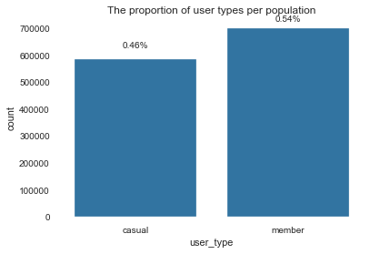

```python
sb.countplot(df['user_type'],color=sb.color_palette()[0])
member=df[df['user_type']=='member'].count()[0]/df['user_type'].shape[0]
casual=df[df['user_type']=='casual'].count()[0]/df['user_type'].shape[0]
pct_string='{:0.2f}%'.format(member)
plt.text(1,750000,pct_string,ha='center',va='top')
pct_string='{:0.2f}%'.format(casual)
plt.text(0,650000,pct_string,ha='center',va='top')
plt.title('The proportion of user types per population')
```

# Weekdays

The graph below shows the proportions of weekdays. It shows the differences in proportions are in range of 3%.

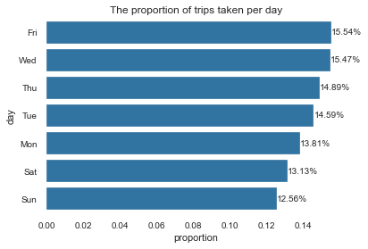

```python
n_observations=df.shape[0]
type_counts=df.day.value_counts()
max_point=type_counts[0]/n_observations
values=np.arange(0,max_point,.02)
value_ticks=['{:0.2f}'.format(v) for v in values]
value_ticks
color=sb.color_palette()[0]
order=df.day.value_counts().index
plt.xticks(n_observations*values,value_ticks);
sb.countplot(data=df,y='day',color=color,order=order);
plt.xticks(n_observations*values,value_ticks);
plt.xlabel('proportion');
for i in range(type_counts.shape[0]):
    count=type_counts[i]
    pct_string='{:0.2f}%'.format(100*count/n_observations)
    plt.text(count+1,i,pct_string,va='center')
plt.title('The proportion of trips taken per day');
```

# Time of day

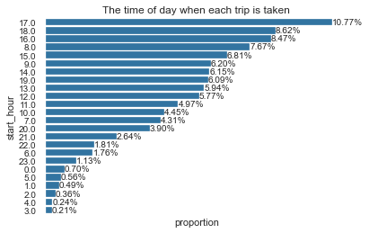

```python
type_counts=sorted(df.start_hour.value_counts(),reverse=True)
max_point=type_counts[0]/n_observations
values=np.arange(0,max_point,.02)
value_ticks=['{:0.2f}'.format(v) for v in values]
value_ticks
color=sb.color_palette()[0]
order=df.start_hour.value_counts().index
sb.countplot(data=df,y='start_hour',color=color,order=order);
plt.xticks([])
plt.xlabel('proportion');
for i in range(len(type_counts)):
    count=type_counts[i]
    pct_string='{:0.2f}%'.format(100*count/n_observations)
    plt.text(count+1,i,pct_string,va='center')
plt.title('The time of day when each trip is taken');
```

# Month of the year

The data being presented represents the first half of 2020. As per the graph, it shows that Feubruary recored the highest proportion as it got 33% of the data, whereas, April came in the last place.

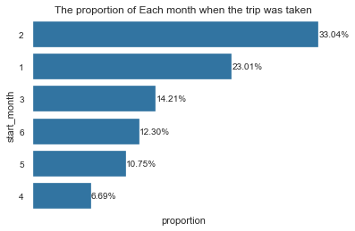

```python
type_counts=sorted(df.start_month.value_counts(),reverse=True)
max_point=type_counts[0]/n_observations
values=np.arange(0,max_point,.02)
value_ticks=['{:0.2f}'.format(v) for v in values]
value_ticks
color=sb.color_palette()[0]
order=df.start_month.value_counts().index
sb.countplot(data=df,y='start_month',color=color,order=order);
plt.xticks([])
plt.xlabel('proportion');
for i in range(len(type_counts)):
    count=type_counts[i]
    pct_string='{:0.2f}%'.format(100*count/n_observations)
    plt.text(count+1,i,pct_string,va='center')
plt.title('The proportion of Each month when the trip was taken');
```

# Duration in minutes:

The histogram below plots the duration of the trip in minutes. It shows that most of the trips were for 0 to 20 minutes, which means that the customers preferred using biks for short trips.

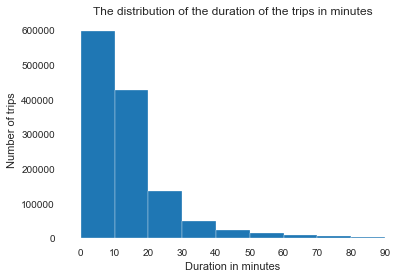

```python
bins=np.arange(0,100,10)
plt.hist(df['duration_minutes'],bins=bins);
plt.xticks(bins,bins);
plt.xlabel('Duration in minutes');
plt.ylabel('Number of trips')
plt.title('The distribution of the duration of the trips in minutes');
```

# distance vs. duration_minutes

the scatter plot below shows that there is a positive correlation between the distance and the duration of the trip in minutes

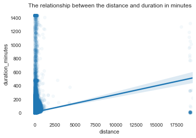

```python
sb.regplot(data=df,x='distance',y='duration_minutes',x_jitter=.4,scatter_kws={'alpha':1/20});
plt.title('The relationship between the distance and duration in minutes');
```

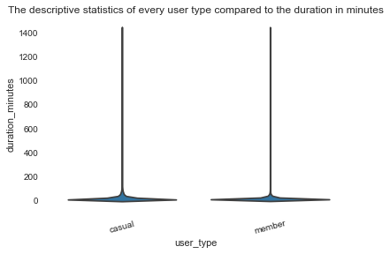

```python
sb.violinplot(data=df,x='user_type',y='duration_minutes',color=sb.color_palette()[0],inner=None);# different variation
plt.xticks(rotation=15);
plt.title('The descriptive statistics of every user type compared to the duration in minutes');
```

# User type vs. day

The graph shows that on average the members have more rides than the casual users except for Saturdays. Which may ignite the need to expand in attracting more casual users to be members.

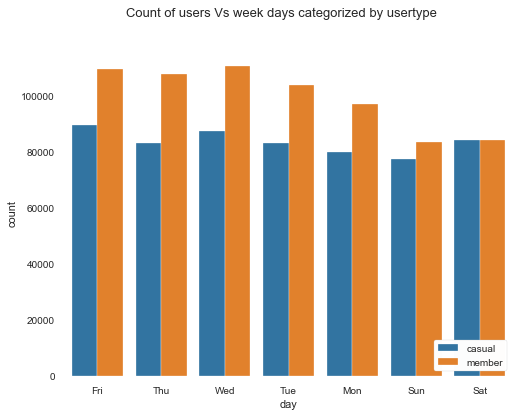

```python
size = (8,6)
ax = sb.countplot(data = df, x='day' ,hue = 'user_type')
ax.legend(loc = 4, ncol = 1, framealpha =3)
fig.suptitle('Count of users Vs week days categorized by usertype', size = 13);
```

# User_type vs. Start_hour

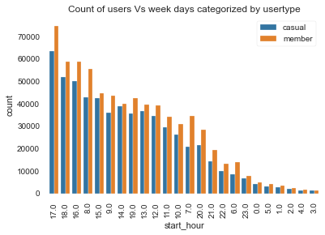

```python
size = (8,6)
ax = sb.countplot(data = df,x='start_hour' ,hue = 'user_type',order=df.start_hour.value_counts().index)
ax.legend(loc = 4, ncol = 1, framealpha =3)
plt.xticks(rotation=90);
plt.title('Count of users Vs week days categorized by usertype');
plt.legend(loc=1)
```

# Multivariate exploration

# The relationship between the duration in minutes, the distance and user type

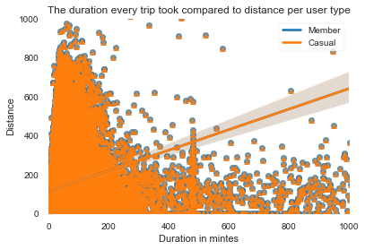

```python
ttype_marker=[['member','o'],
             ['casual','^']]
for ttype,marker in ttype_marker:
    sub=df.loc[df['user_type']==ttype]
    sb.regplot(data=df,x='duration_minutes',y='distance',x_jitter=.04,fit_reg=True,marker=marker)
plt.legend(['Member','Casual'],)
plt.title('The duration every trip took compared to distance per user type');
#plt.yscale('log');
tick=[20,60,140,280,560,1000]
#plt.xscale('log');

plt.ylabel('Distance');
plt.xlabel('Duration in mintes');
plt.ylim(0,1000);
plt.xlim(0,1000);
```

# The distibution of duration in minutes for every day in every month per user type

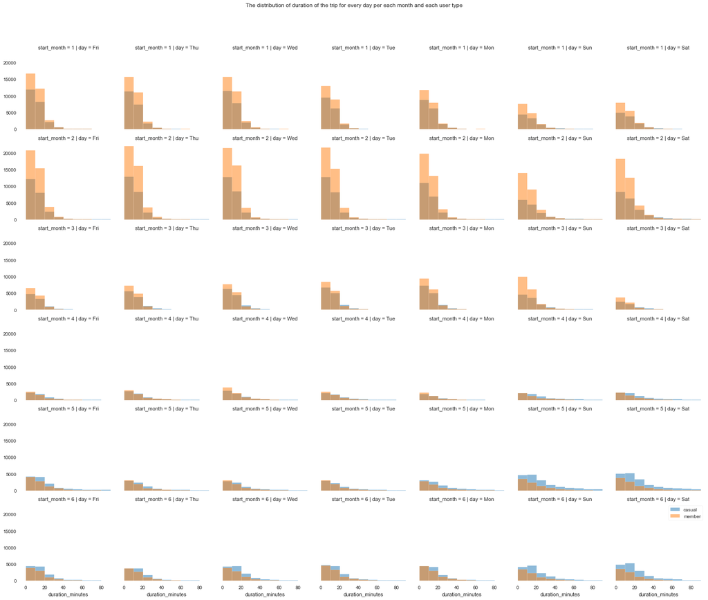

```python
g=sb.FacetGrid(data=df,col='day',hue='user_type',row='start_month')
bins=np.arange(0,100,10)
g.map(plt.hist,'duration_minutes',bins=bins,alpha=.5)
plt.legend();
plt.subplots_adjust(top=0.9)
g.fig.suptitle('The distribution of duration of the trip for every day per each month and each user type')
```